# Assessment 2

Bharath Arun Gandhimani

2025-09-13

Assignment Task: The dataset for this assignment is in the file World_development_Indicators.csv and it can be accessed from the Assessments page on Moodle.

```r
# Load the tidyverse library for data manipulation
library(tidyverse)
wdi_data <- read.csv("World_Development_Indicators.csv", header = TRUE, stringsAsFactors = FALSE, check.names = FALSE)
```

## Question 1

How many unique values are there in the Series Name column of the data file? (6 marks)

```r
length(unique(wdi_data$"Series Name"))
```

```
## [1] 67
```

## Question 2

How many comments in the Trend Description column describe a decreasing trend with positive feedback? (5 marks)

Explanation:

This code finds out how many trend descriptions talk about both a decreasing trend and something positive at the same time. First, it cleans each description by making it lowercase, removing extra spaces, and trimming blank spaces at the start or end. Then, it uses two sets of keywords: one for words about decline (like “fall”, “drop”, “decrease”), and another for positive words (like “good”, “improve”, “progress”). Using grepl, the code checks each description for matches with both sets. If a description has both a decreasing keyword and a positive keyword, it gets counted. The final result is the number of such “decreasing-but-positive” cases in the data.

```r
# Clean the 'Trend Description' text: lowercase, collapse spaces, and trim
clean_desc <- tolower(wdi_data$`Trend Description`)
clean_desc <- gsub("\\s+", " ", clean_desc)
clean_desc <- trimws(clean_desc)

# Regex pattern for decreasing trend words (Used Google to search for decreasing trend words)
dec_re <- "(decreas|declin|fall|drop|reduc|downward|downtrend|lower(ing)?|diminish|shrink|plummet|plung|subsiding|abating|\\bdown\\b|\\bdownturn\\b)"

# Regex pattern for positive feedback words (Used Google to search for decreasing trend words)
pos_re <- "(positive|good|encourag|favo(u)?rable|improv|resilien|progress|promis|optimis|welcome|heartening|better|benefit|success|gain|achiev|encouraging|significant|meaningful|progress|on track)"

# Create logical masks for each condition using grepl with perl=TRUE
dec_mask <- grepl(dec_re, clean_desc, perl = TRUE)
pos_mask <- grepl(pos_re, clean_desc, perl = TRUE)

# Combine masks - TRUE if both conditions are met
both_mask <- dec_mask & pos_mask

# Calculate the count of matching rows (NA removed)
count_decreasing_positive <- sum(both_mask, na.rm = TRUE)

# Output the result as a single numeric value
print(count_decreasing_positive)
```

```
## [1] 1298
```

## Question 3

We want to explore the GDP series data, i.e., values with the Series Name ’GDP (current US$)'. Specifically, instead of considering all countries, we will focus on: (1) the top five countries and (2) the bottom five countries based on their GDP (current US$) values in 2018. Please present these 10 countries, along with their GDP values, in a single table and create a suitable chart. (4 marks)

Explanation:

This code extracts and visualizes GDP data for the year 2018 from the WDI dataset. First, it filters the data to keep rows where the series is “GDP (current US$)” and the 2018 GDP value is not missing. Then it picks the relevant columns: country name, country code, and 2018 GDP values, and sorts the countries by their GDP in descending order. After that, it isolates the 5 countries with the highest GDP (top5) and the 5 with the lowest GDP (bottom5) and prints their data tables.

Next, it defines a helper function to format large numbers with commas, making the GDP values easier to read. Finally, it plots two horizontal bar charts: one showing the top 5 GDP countries with green bars, and one showing the bottom 5 countries with red bars. The bars are sorted so the largest GDP is at the top for better visualization, and the y-axis labels use the helper to show the GDP numbers with commas. This helps easily compare the highest and lowest GDP countries in 2018.

```r
library(dplyr)
library(ggplot2)

# Filter out NA values and select GDP data for 2018
gdp_2018 <- wdi_data %>%
  filter(`Series Name` == "GDP (current US$)" & !is.na(`2018`)) %>%
  select(`Country Name`, `Country Code`, `2018`) %>%
  arrange(desc(`2018`))

# Separate top 5 and bottom 5 countries
top5 <- head(gdp_2018, 5)
bottom5 <- tail(gdp_2018, 5)

# Print tables
print("Top 5 Countries by GDP in 2018")
```

```
## [1] "Top 5 Countries by GDP in 2018"
```

```r
print(top5)
```

```
##     Country Name Country Code     2018
## 1  United States          USA 2.06e+13
## 2          China          CHN 1.39e+13
## 3          Japan          JPN 4.95e+12
## 4        Germany          DEU 3.96e+12
## 5 United Kingdom          GBR 2.86e+12
```

```r
print("Bottom 5 Countries by GDP in 2018")
```

```
## [1] "Bottom 5 Countries by GDP in 2018"
```

```r
print(bottom5)
```

```
##         Country Name Country Code      2018
## 206            Palau          PLW 280435700
## 207 Marshall Islands          MHL 221588900
## 208         Kiribati          KIR 196737896
## 209            Nauru          NRU 124021394
## 210           Tuvalu          TUV  42588165
```

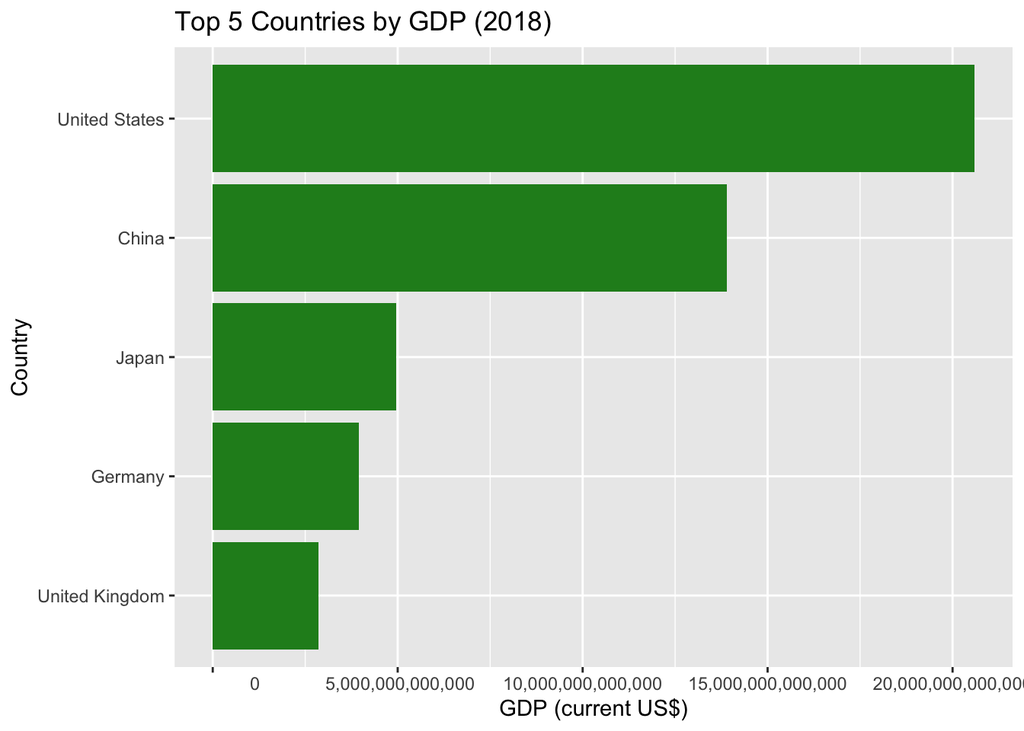

```r
# Combine the two sets into one table
gdp_table <- rbind(top5, bottom5)

# Helper function to format numbers (Took help from Google to format numbers)
number_with_commas <- function(x) {
  format(x, big.mark = ",", scientific = FALSE)
}

# Plot for top 5 countries
ggplot(top5, aes(x = reorder(`Country Name`, `2018`), y = `2018`)) +
  geom_bar(stat = "identity", fill = "forestgreen") +
  coord_flip() +
  scale_y_continuous(labels = number_with_commas) +
  labs(title = "Top 5 Countries by GDP (2018)", x = "Country", y = "GDP (current US$)")
```

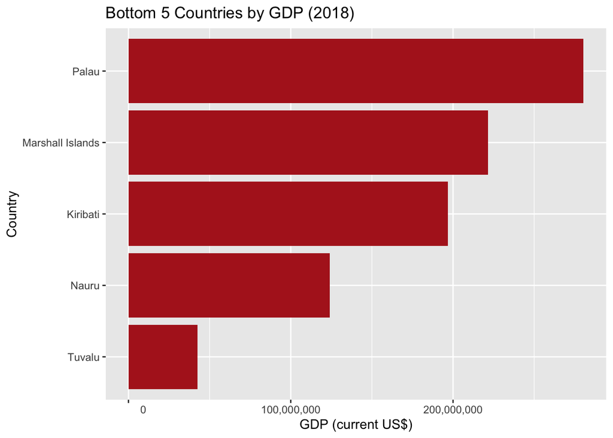

```r
# Plot for bottom 5 countries
ggplot(bottom5, aes(x = reorder(`Country Name`, `2018`), y = `2018`)) +
  geom_bar(stat = "identity", fill = "firebrick") +
  coord_flip() +
  scale_y_continuous(labels = number_with_commas) +
  labs(title = "Bottom 5 Countries by GDP (2018)", x = "Country", y = "GDP (current US$)")
```

## Question 4

Use a single R function or command to display the statistical information (i.e., minimum, maximum, and mean) of GDP values for each year from 2010 to 2019 for the 10 countries identified in Question 3 (Note: You may use multiple functions/commands to prepare the pre-processed data table, but when you compute and display the statistical information, you need to use a single R function/command.) (3 marks)

Explanation:

This code calculates summary statistics for GDP data from 2010 to 2019 for the countries in the previously created gdp_table (which contains the top 5 and bottom 5 GDP countries). Specifically:

-> It filters the original WDI dataset for rows where the series name is “GDP (current US$)” and where the country name matches one of those in gdp_table. -> Then, it extracts the GDP values for the years 2010 to 2019. -> For each year (2010-2019), it applies a function that computes the minimum, maximum, and mean GDP across the selected countries, ignoring missing values. -> Finally, it transposes the result (t()) so the output shows years as rows and summary statistics (Min, Max, Mean) as columns. -> This gives a concise table showing GDP trends over the decade for those countries, summarizing how their GDP changed each year.

```r
t(sapply(wdi_data[wdi_data$`Series Name` == "GDP (current US$)" & wdi_data$`Country Name` %in% gdp_table$`Country Name`, as.character(2010:2019)],
     function(x) c(Min = min(x, na.rm=TRUE), Max = max(x, na.rm=TRUE), Mean = mean(x, na.rm=TRUE))))
```

```
##           Min      Max         Mean
## 2010 31823519 1.45e+13 3.217058e+12
## 2011 38711810 1.55e+13 3.562066e+12
## 2012 37671775 1.62e+13 3.716072e+12
## 2013 37509075 1.68e+13 3.804073e+12
## 2014 37290608 1.75e+13 3.981075e+12
## 2015 35492074 1.82e+13 3.998076e+12
## 2016 36547800 1.87e+13 4.098081e+12
## 2017 40619252 1.95e+13 4.301084e+12
## 2018 42588165 2.06e+13 4.627087e+12
## 2019 47271463 1.43e+13 2.894541e+12
```

## Question 5

In which year did China record its maximum GDP? Which country shows the most largest increase in CO2 emissions over years? (3 marks).

Explanation:

The first part of the code finds the year when China had its highest GDP:

-> It filters the WDI data for rows where the country is “China” and the series is “GDP (current US$)” and extracts GDP values for years 1960 to 2019. -> It uses which.max to get the index of the maximum GDP value. -> Then, it finds the year name corresponding to this index. -> Finally, it prints the year when China’s GDP peaked.

The second part identifies the country with the largest increase in CO2 emissions per capita over all years:

-> It filters data for the CO2 emissions series. -> Extracts columns for country and years 1960-2019. -> Removes rows where all years are missing. -> Calculates the difference between max and min CO2 emissions for each country. -> Finds the country with the largest increase using which.max. -> Prints the country name.

```r
# In which year did China record its maximum GDP?
china_gdp <- wdi_data[wdi_data$`Country Name` == "China" & wdi_data$`Series Name` == "GDP (current US$)", as.character(1960:2019)]
year_max_gdp <- names(china_gdp)[which.max(china_gdp[1, ])]
print(year_max_gdp)
```

```
## [1] "2019"
```

```r
# Which country shows the largest increase in CO2 emissions over years?
co2_gdp <- wdi_data[wdi_data$`Series Name` == "CO2 emissions (metric tons per capita)", ]
years <- as.character(1960:2019)
co2_gdp_selected <- co2_gdp[, c("Country Name", years)]
valid_rows <- apply(co2_gdp_selected[, -1], 1, function(x) any(!is.na(x)))
co2_gdp_valid <- co2_gdp_selected[valid_rows, ]
co2_diff <- apply(co2_gdp_valid[, -1], 1, function(x) {
  max(x, na.rm = TRUE) - min(x, na.rm = TRUE)
})
largest_increase_country <- co2_gdp_valid$`Country Name`[which.max(co2_diff)]
print(largest_increase_country)
```

```
## [1] "Aruba"
```

## Question 6

Let’s investigate life expectancy, fertility rate and GDP:

A. Identify the top 5 countries with the strongest relationship between life expectancy and GDP values across years. Please display both the countries and the corresponding values used to measure the strength of the relationship. (3 marks)

Explanation:

This code analyzes the relationship between life expectancy and GDP across countries using WDI data. It first filters and selects relevant data on life expectancy and GDP for all years 1960–2019, then restructures them from wide format (one column per year) to long format (one row per country-year). The two datasets are joined by country and year, keeping only rows where both measures are present. It then calculates the Pearson correlation between life expectancy and GDP for each country, but only if the country has data for at least two years. Finally, it sorts countries by the absolute correlation (strength of relationship) and shows the top 5 countries with the strongest correlation between life expectancy and GDP across time. This helps highlight which countries exhibit the closest links between economic performance and health outcomes.

```r
library(dplyr)
library(tidyr)

life_exp <- wdi_data %>%
  filter(`Series Name` == "Life expectancy at birth, total (years)") %>%
  select(`Country Name`, as.character(1960:2019))

gdp <- wdi_data %>%
  filter(`Series Name` == "GDP (current US$)") %>%
  select(`Country Name`, as.character(1960:2019))

life_exp_long <- life_exp %>%
  pivot_longer(cols = -`Country Name`, names_to = "Year", values_to = "LifeExpectancy")

gdp_long <- gdp %>%
  pivot_longer(cols = -`Country Name`, names_to = "Year", values_to = "GDP")

joined_data <- inner_join(life_exp_long, gdp_long, by = c("Country Name", "Year")) %>%
  filter(!is.na(LifeExpectancy), !is.na(GDP)) %>%
  group_by(`Country Name`) %>%
  filter(n() >= 2) %>%
  summarize(Correlation = cor(LifeExpectancy, GDP)) %>%
  arrange(desc(abs(Correlation))) %>%
  slice_head(n = 5)

print(joined_data)
```

```
## # A tibble: 5 × 2
##   `Country Name` Correlation
##   <chr>                <dbl>
## 1 Palau               -1
## 2 Guam                 0.997
## 3 Djibouti             0.992
## 4 Tanzania             0.988
## 5 Dominica             0.987
```

B. Determine the top 5 countries that exhibit the most significant decreasing trend in fertility rate since 2010. Please display both the countries and the corresponding values used to quantify the decreasing trend. (3 marks)

Explanation:

This code analyzes trends in fertility rates from 2010 to 2019 by country. It filters the WDI data to keep only fertility rate records over that period, reshapes the data into a long format with one row per country-year, and removes missing values. Then, for each country, it fits a simple linear regression of fertility rate on year to estimate the slope, which reflects the annual change in fertility rate. Countries with a negative slope are experiencing decreasing fertility rates over time. Finally, the code sorts these slopes ascendingly and selects the top 5 countries with the steepest declines in fertility rates, printing these results. This helps identify countries with the most significant downward trends in birth rates recently.

```r
library(dplyr)
library(tidyr)

# Filter for fertility rate data from 2010 onward
fertility_data <- wdi_data %>%
  filter(`Series Name` == "Fertility rate, total (births per woman)") %>%
  select(`Country Name`, `Series Name`, `2010`:`2019`)

# Pivot longer for regression
fertility_long <- fertility_data %>%
  pivot_longer(cols = `2010`:`2019`, names_to = "Year", values_to = "Fertility_Rate") %>%
  mutate(Year = as.integer(Year)) %>%
  filter(!is.na(Fertility_Rate))

# Compute trend (slope) for each country using linear regression
fertility_trends <- fertility_long %>%
  group_by(`Country Name`) %>%
  summarize(
    slope = if (n() > 1) {
      coef(lm(Fertility_Rate ~ Year))[2]
    } else {
      NA_real_
    },
    .groups = "drop"
  ) %>%
  filter(!is.na(slope)) %>%
  arrange(slope) # ascending slope: most negative first

# Top 5 countries with strongest decreasing fertility rate trend
top5_decreasing <- head(fertility_trends, 5)

print(top5_decreasing)
```

```
## # A tibble: 5 × 2
##   `Country Name`  slope
##   <chr>           <dbl>
## 1 Afghanistan    -0.185
## 2 Uganda         -0.146
## 3 Malawi         -0.135
## 4 Sierra Leone   -0.114
## 5 Ethiopia       -0.110
```

## Question 7

The population density of countries has varied over time. Please divide the years into the following 6 periods and label them as Period 1-6, respectively, as shown below: i. 1960 - 1969 : Period 1 ii. 1970 - 1979 : Period 2 iii. …… iv. 2010 - 2019 : Period 6 After that, write the code to compute the average population density value for each country within each period and display the first 10 data records of the output. Please make sure you sort the average population density value in a descending order for the output. (3 marks)

```r
library(dplyr)
library(tidyr)

# Filter population density series only
pop_density <- wdi_data %>%
  filter(`Series Name` == "Population density (people per sq. km of land area)") %>%
  select(`Country Name`, `1960`:`2019`)

# Pivot longer: from wide years to long Year-Value pairs
pop_long <- pop_density %>%
  pivot_longer(cols = `1960`:`2019`, names_to = "Year", values_to = "Value") %>%
  mutate(Year = as.integer(Year))

# Define periods based on Year values
pop_long <- pop_long %>%
  mutate(Period = case_when(
    Year >= 1960 & Year <= 1969 ~ "Period 1",
    Year >= 1970 & Year <= 1979 ~ "Period 2",
    Year >= 1980 & Year <= 1989 ~ "Period 3",
    Year >= 1990 & Year <= 1999 ~ "Period 4",
    Year >= 2000 & Year <= 2009 ~ "Period 5",
    Year >= 2010 & Year <= 2019 ~ "Period 6",
    TRUE ~ NA_character_
  ))

# Group by Country and Period to calculate average population density, then sort descending
pop_period_avg <- pop_long %>%
  group_by(`Country Name`, Period) %>%
  summarize(Avg_Pop_Density = mean(Value, na.rm = TRUE), .groups = "drop") %>%
  arrange(desc(Avg_Pop_Density))

# Display first 10 rows
head(pop_period_avg, 10)
```

```
## # A tibble: 10 × 3
##    `Country Name`   Period   Avg_Pop_Density
##    <chr>            <chr>              <dbl>
##  1 Macao SAR, China Period 6          19250.
##  2 Macao SAR, China Period 4          19080.
##  3 Monaco           Period 6          18373.
##  4 Macao SAR, China Period 5          17602.
##  5 Monaco           Period 5          16611.
##  6 Monaco           Period 4          15091.
##  7 Macao SAR, China Period 3          14031.
##  8 Monaco           Period 3          13998.
##  9 Monaco           Period 2          12311.
## 10 Macao SAR, China Period 2          12115.
```

## Question 8

Create a chart that illustrates the trend of GDP data (i.e. GDP (current US$)) for the USA. Identify and address any issues in the data, and justify your approach in resolving them. (4 marks)

```r
library(dplyr)
library(ggplot2)
library(tidyr)

# Filter data for USA and GDP (current US$)
usa_gdp <- wdi_data %>%
  filter(`Country Name` == "United States", `Series Name` == "GDP (current US$)") %>%
  select(`Country Name`, `Series Name`, `1960`:`2019`)

# Pivot longer for plotting
usa_gdp_long <- usa_gdp %>%
  pivot_longer(cols = `1960`:`2019`, names_to = "Year", values_to = "GDP") %>%
  mutate(Year = as.integer(Year))

# Check for missing values
missing_values <- sum(is.na(usa_gdp_long$GDP))
print(paste("Number of missing GDP values:", missing_values))
```

```
## [1] "Number of missing GDP values: 1"
```

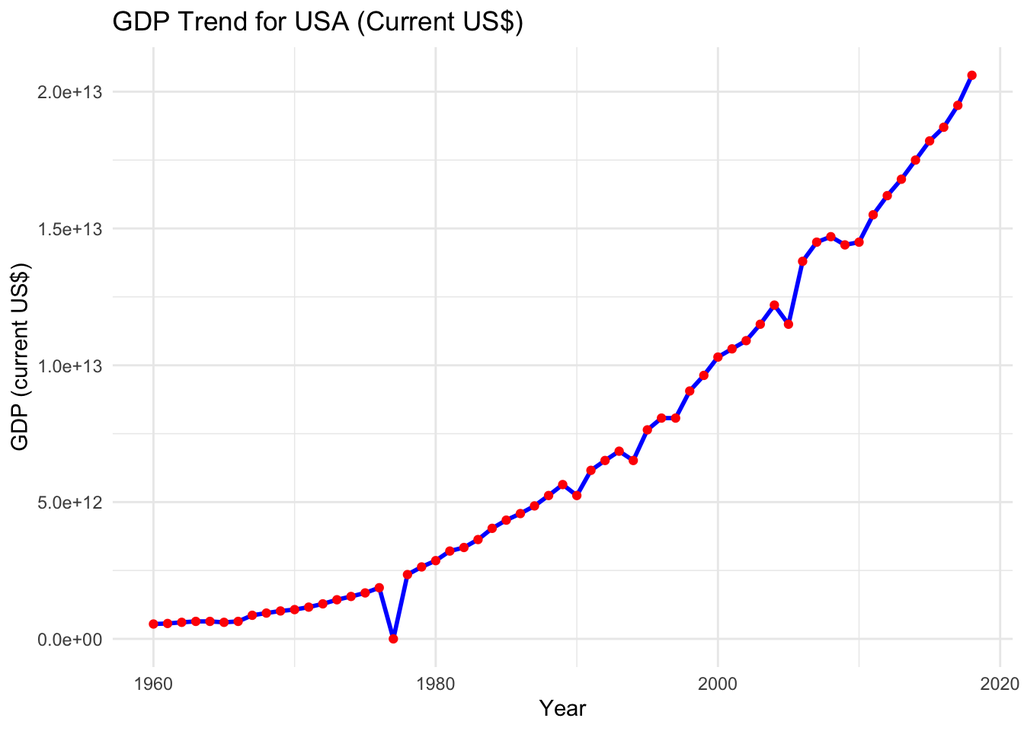

```r
# If missing values exist, you might choose to interpolate or omit.
# Here, we'll omit them for simplicity.
usa_gdp_long_clean <- usa_gdp_long %>%
  filter(!is.na(GDP))

# Plot GDP trend over years
ggplot(usa_gdp_long_clean, aes(x = Year, y = GDP)) +
  geom_line(color = "blue", size = 1) +
  geom_point(color = "red") +
  labs(title = "GDP Trend for USA (Current US$)",
       x = "Year",
       y = "GDP (current US$)") +
  theme_minimal()
```

## Question 9

Using both the original datasets and external sources, investigate the factors influencing the yearly trend of GDP (current US$) values in selected countries. You may choose one or more countries for this investigation and should analyse at least 20 years of GDP data. Marks will be awarded based on the depth of your analysis (including discussion) and the strength of your reasoning (i.e., how insights and conclusions are drawn). Note: Please provide source links for any external data used. (7 marks).

Explanation:

Population and Labor Force A growing population means more workers and consumers, sustaining economic expansion and boosting demand. Labor market participation and immigration policy shape how much this contributes to GDP growth.

Consumer Spending & Business Investment More than two-thirds of U.S. GDP comes from consumer spending. High confidence, low unemployment, and accessible credit fueled expansion until 2008. After the recession, recovery was helped by renewed investment and consumer support.

Government Policy and Crisis Response During downturns, the government used strong fiscal stimulus (via direct payments, increased spending, and tax cuts) and the Federal Reserve slashed interest rates to support borrowing and investment. These interventions shortened recessions and boosted recoveries.

Technological Progress Rising productivity—especially in technology and services—helped keep U.S. growth strong even when other sectors lagged. Investments in tech were key to post-2010 acceleration.

External Shocks Global crises like the Great Recession and COVID-19 led to GDP declines, mostly through lost jobs and reduced investment. However, the quick and massive policy response enabled rapid recoveries in subsequent years.

Reasoning & Insights GDP trends in the U.S. have been driven by both underlying strengths (population, innovation, flexible policy) and ability to respond swiftly to economic shocks. The data reveals that policy action and robust consumer confidence are crucial for rapid post-crisis recoveries. By analyzing the curve and cited research, it’s clear that the U.S. economy’s resilience is a result of both structural factors and successful government intervention.

Source Links U.S. GDP Growth Rate Trend — Trading Economics - https://tradingeconomics.com/united-states/gdp-growth

U.S. GDP Growth by President — Investopedia - https://www.investopedia.com/gdp-growth-by-president-8604042

Economy of the United States — Wikipedia - https://en.wikipedia.org/wiki/Economy_of_the_United_States

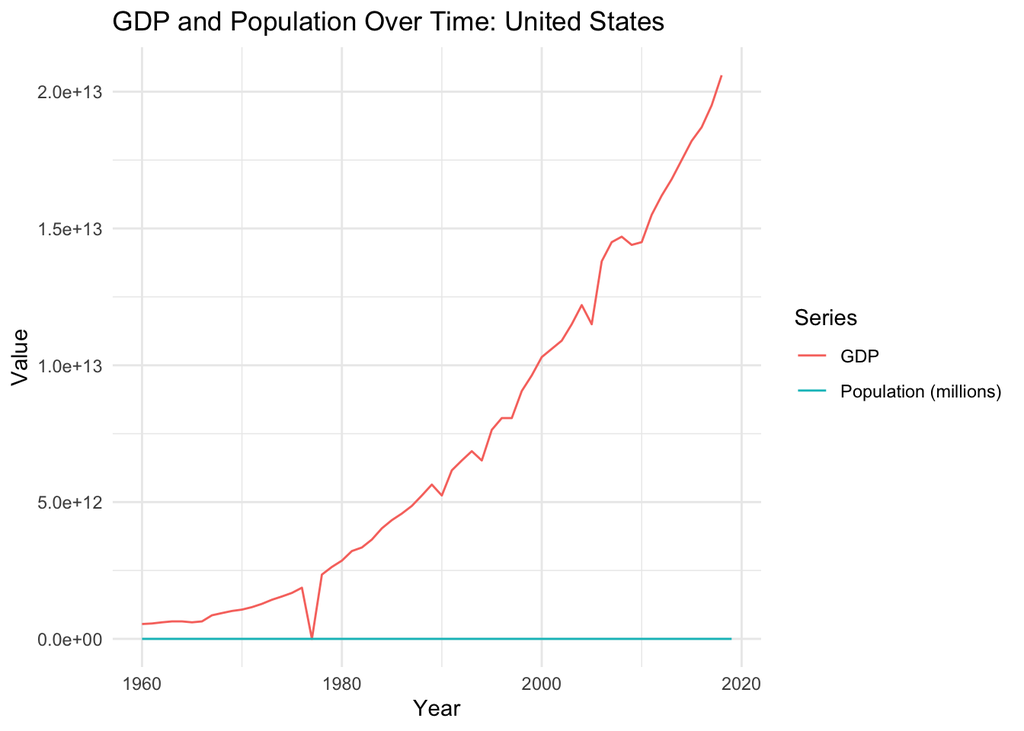

```r
library(dplyr)
library(tidyr)
library(ggplot2)

selected_country <- "United States"
factors <- c("GDP (current US$)", "Population, total")

# Filter data
wdi_filtered <- wdi_data %>%
  filter(`Country Name` == selected_country,
         `Series Name` %in% factors) %>%
  select(`Country Name`, `Series Name`, `1960`:`2019`)

# Pivot data to long format
data_long <- wdi_filtered %>%
  pivot_longer(cols = `1960`:`2019`, names_to = "Year", values_to = "Value") %>%
  mutate(Year = as.integer(Year))

# Pivot wider with cleaned column names
data_wide <- data_long %>%
  pivot_wider(names_from = `Series Name`, values_from = Value)

# Clean column names to match your output
names(data_wide) <- c("Country_Name", "Year", "Population_total", "GDP_")

# Plot GDP and Population
ggplot(data_wide, aes(x = Year)) +
  geom_line(aes(y = GDP_, color = "GDP")) +
  geom_line(aes(y = Population_total / 1e6, color = "Population (millions)")) +
  labs(title = paste("GDP and Population Over Time:", selected_country),
       y = "Value",
       color = "Series") +
  theme_minimal()
```